# El arte de modelar

Una exploración en profundidad sobre el aprendizaje automático para la creación de modelos predictivos

Autor/a

Grupo A

Fecha de publicación

16 de diciembre de 2024

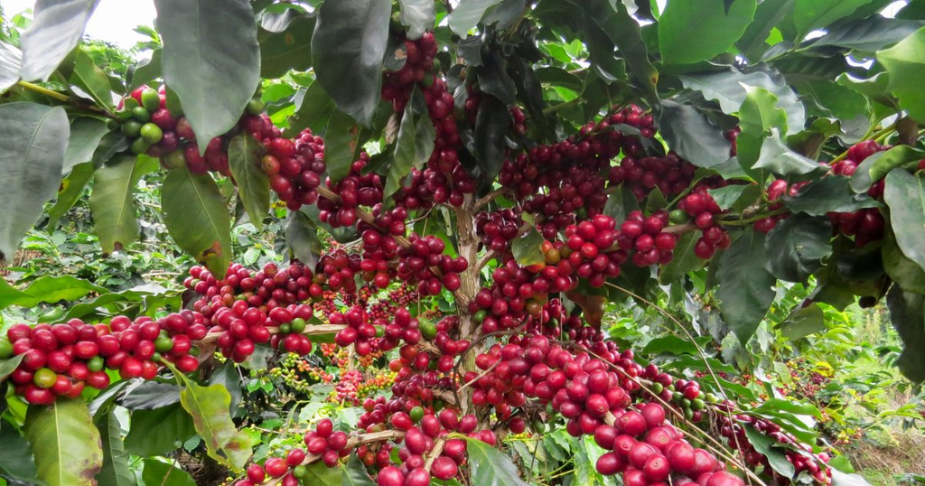

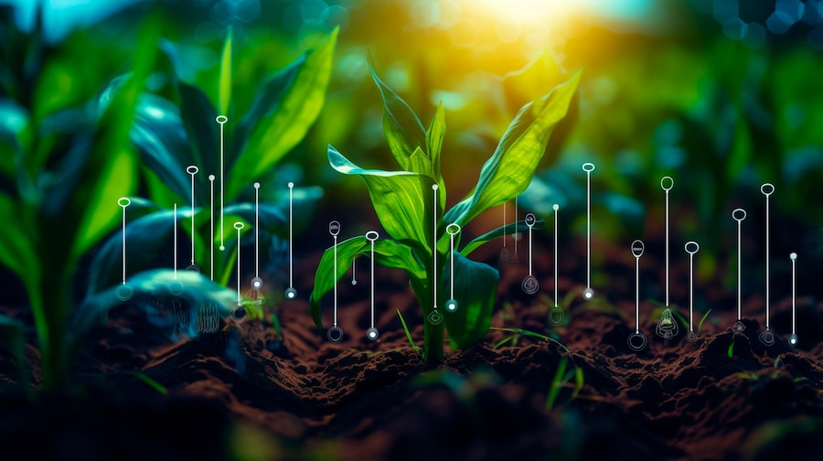

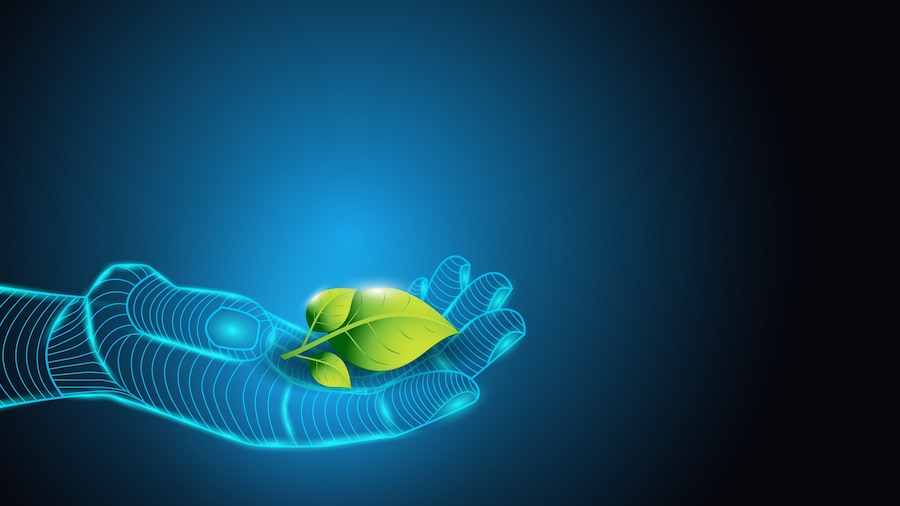

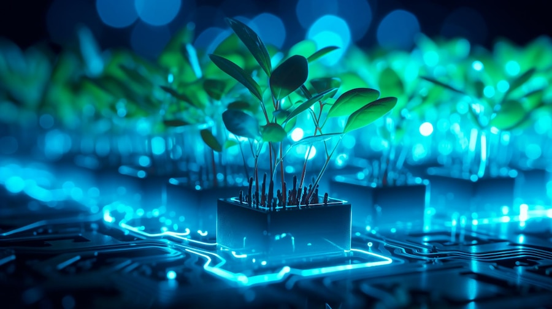

# 1 Introducción

En el contexto del análisis de datos y aprendizaje automático, herramientas como **ImageJ**, **Anaconda**, **Python** y **Label Studio** desempeñan un papel crucial. Cada una ofrece funcionalidades específicas para diferentes etapas de un proyecto: desde la adquisición y preprocesamiento de imágenes hasta la anotación de datos y el entrenamiento de modelos. Este informe presenta una guía detallada sobre la instalación, configuración y uso de estas herramientas. Además, se explicará el procedimiento para entrenar un modelo con datos anotados en Label Studio, integrándolos a un entorno en RStudio.

# 2 Programas

## 2.1 ImageJ

ImageJ es un software de código abierto diseñado para el análisis de imágenes multidimensionales. Es ampliamente utilizado en investigaciones biomédicas y científicas debido a su capacidad para realizar tareas como la medición de áreas, el conteo de partículas y la aplicación de transformaciones a imágenes.

**Usos principales**

- Análisis cuantitativo de imágenes (medición de áreas, perímetros y más).
- Aplicación de filtros para mejorar la calidad de las imágenes.
- Automatización de tareas repetitivas mediante macros.
- Segmentación de regiones específicas en imágenes.

## 2.2 Anaconda

Anaconda es una distribución de Python y R que simplifica la gestión de bibliotecas y entornos de desarrollo. Incluye herramientas como Jupyter Notebook y Spyder, y se utiliza principalmente en análisis de datos, aprendizaje automático y otras aplicaciones científicas.

[figure not shown]

**Usos principales** - Creación de entornos virtuales independientes.

- Instalación de herramientas como Jupyter Notebook y bibliotecas para análisis y aprendizaje automático (Scikit-learn, TensorFlow, etc.).
- Gestión eficiente de proyectos con distintas configuraciones.

## 2.3 Label Studio

Label Studio es una herramienta de código abierto para la anotación de datos. Permite realizar tareas de etiquetado en texto, imágenes, audio y video, facilitando la creación de conjuntos de datos listos para el entrenamiento de modelos de aprendizaje automático.

[figure not shown]

**Usos principales** - Creación de conjuntos de datos etiquetados para entrenar modelos de IA.

- Colaboración en equipo para garantizar anotaciones consistentes.
- Exportación de datos en formatos como JSON o CSV para integrarlos en flujos de trabajo de aprendizaje automático.

# 3 Instalación de herramientas para anotación de datos

## 3.1 Instalación de Anaconda

- Descargar el instalador desde `https://www.anaconda.com/`
- Ejecutar el archivo descargado
- Seguir las instrucciones del instalador
- Verificar la instalación ejecutando conda list en el terminal

## 3.2 Instalación de Label Studio

Label Studio ofrece cuatro métodos de instalación: a través de pip, brew, Git y Docker. En esta guía, nos centraremos en el método de instalación de pip. Para instalar Label Studio a través de pip, ejecute el siguiente comando:

`pip install label-studio`

Una vez que haya instalado Label Studio, puede ejecutar la aplicación utilizando el siguiente comando:

`label-studio`

Se abrirá la aplicación Label Studio:

[figure not shown]

Cuando abras Label Studio por primera vez, se te solicitará que crees una cuenta. Haz clic en “Registrarse” si aún no tienes una cuenta.

# 4 Subir imágenes a Label Studio

Antes de cargar imágenes para realizar anotaciones, debemos crear un proyecto en el que se almacenarán nuestras imágenes. Haga clic en el botón “Crear proyecto” en la página de inicio de Label Studio:

[figure not shown]

A continuación, elija un nombre para su proyecto. Si lo desea, especifique una descripción para su proyecto.

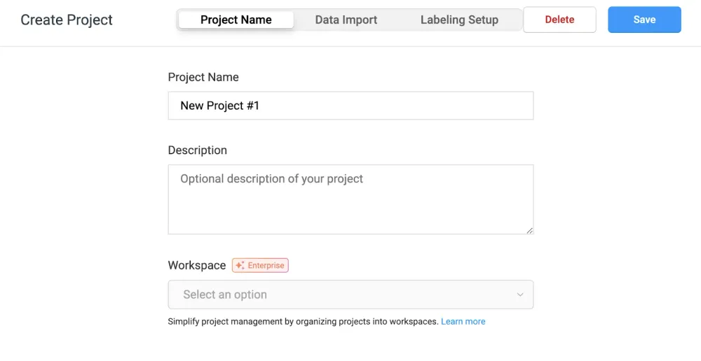

A continuación, haga clic en **Data import**. Aquí, puede cargar imágenes y videos en una variedad de formatos para usar en el etiquetado.

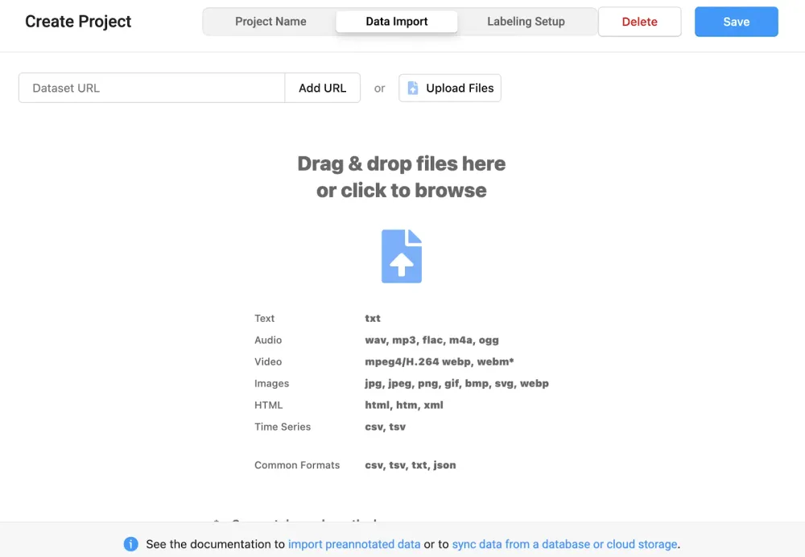

Puede cargar hasta 100 imágenes a la vez mediante la interfaz web.

A continuación, haga clic en “Configuración de etiquetado” y elija un tipo de tarea.En nuestro caso elegimos **Semantic Segmentation with Polygons**

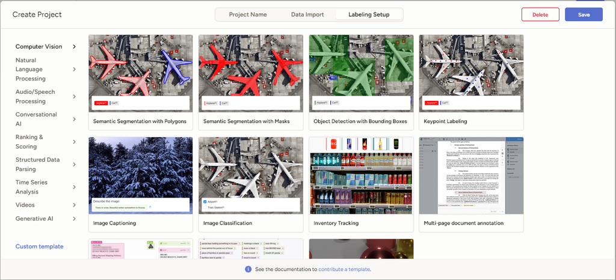

Una vez que haya seleccionado un tipo de tarea, aparecerá una interfaz de usuario del entorno de etiquetado para el tipo de tarea elegido.

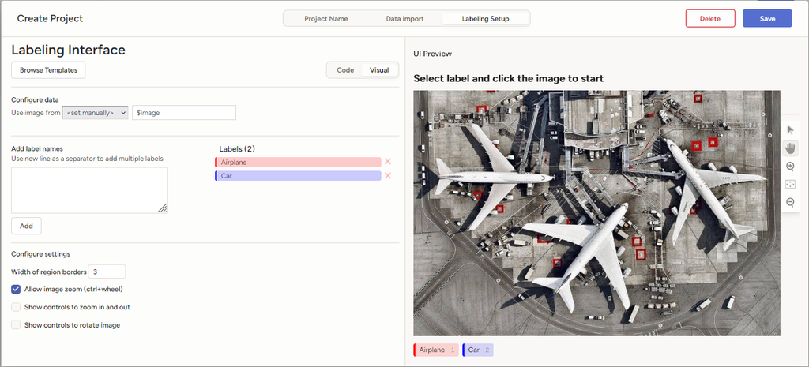

En la barra lateral, elimine las etiquetas predeterminadas y agregue las etiquetas que agregará a las imágenes en su conjunto de datos. Para esta guía, agregaremos dos etiqueta:

`leaf`

`coin`

Cuando esté listo, haga clic en “Guardar” para guardar su configuración e ingresar a la herramienta de etiquetado.

Para comenzar a etiquetar, haz clic en “Etiquetar todas las tareas” en el panel de control de tu proyecto. Si quieres etiquetar una imagen específica, haz clic en la imagen que deseas etiquetar.

[figure not shown]